# THE COMPLEXITIES OF INCOME IMBALANCE: Factors that Shape Economic Inequalities

- Show All Code
- Hide All Code
- View Source

Author

Ezeomataude Somtochukwu Blessing

# 1 Introduction

This analysis consists of a modified snapshot of data collected during a household census conducted in England in 2021.Our mission is to investigate the causes of economic inequality and identify the different aspects of income imbalances. Our goal is to provide light on the complex nature of income distribution and its relationships with different factors through visual investigations and perceptive analysis. To achieve this objective, visual representations such as charts and plots will be employed. The report will be prepared using Quarto. The creation of compelling and informative data visualizations will be facilitated by the ggplot2 (Wickham 2016) and ggthemes package (Arnold 2021), both integral components of the tidyverse - a collection of R packages designed for data analysis, manipulation, and visualization (Wickham et al. 2019). The referenced book (Wickham, Çetinkaya-Rundel, and Grolemund (2023)) served as a crucial resource, offering guidance on effectively navigating R for data analysis.

# 2 Data Exploration and Preprocessing

```r
library(tidyverse)
library(ggplot2)
library(ggthemes)
library(skimr)
library(scales)
library(corrplot)
library(readr)
```

```r
data_1 <- read_csv("C:/Users/mango/Downloads/Data Science/Data Science/data-1.csv")
```

```r
# any(duplicated(data_1))
```

```r
null_values <- is.na(data_1)
null_values
```

```r
newdata <- data_1[complete.cases(data_1), ]
view(newdata)
```

## 2.1 Feature Engineering:

To enhance visualization and better analyze the age feature, I opted to create another column by categorizing the age feature into distinct age brackets such as Children, Teenagers, Young Adults, Middle-Aged Adults, and Older Adults. This grouping allows for a more comprehensive and meaningful visualization of the data.

```r
newdata1 <- newdata |>
  mutate(Age_Group = case_when(
    Age >= 0 & Age <= 15 ~ "Children",
    Age >= 16 & Age <= 20 ~ "Teenagers",
    Age >= 21 & Age <= 39 ~ "Young Adults",
    Age >= 40 & Age <= 59 ~ "Adult (Middle Age)",
    Age >= 60 ~ "Old Age",
    TRUE ~ "Unknown"
  ))
```

# 3 Income Distribution by Age:

```r
Edu_data <- newdata1 |>
  group_by(`Highest Ed`, Age_Group) |>
  summarize(avg_income = mean(INC), n=n())
```

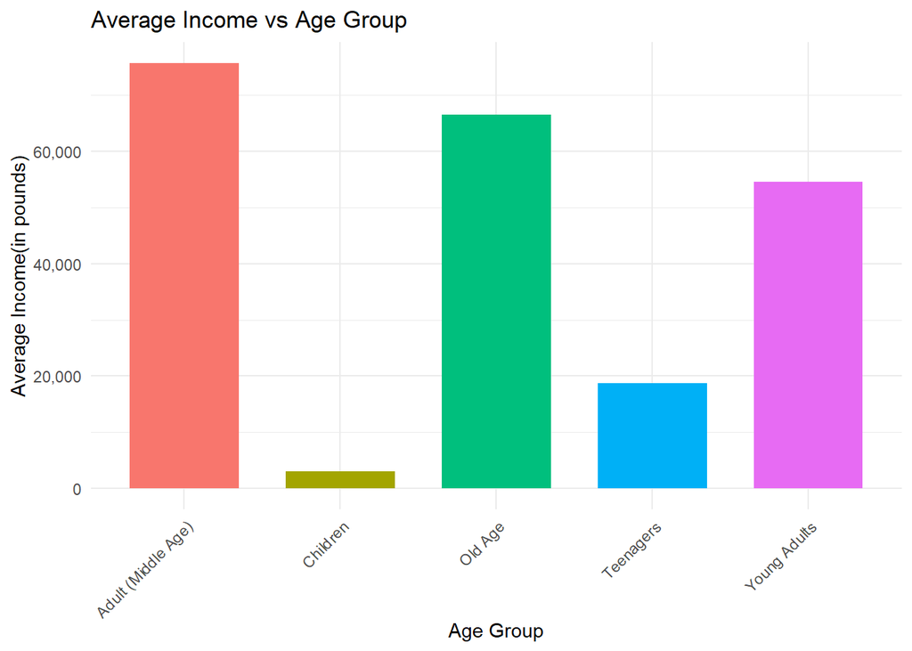

```r
ggplot(Edu_data, aes(x = Age_Group, y = avg_income, fill = Age_Group)) +
  geom_bar(stat = "identity", position = "dodge", width = 0.7) +
  labs(
    title = "Average Income vs Age Group",
    x = "Age Group",
    y = "Average Income(in pounds)"
  ) +
  theme_minimal() +
  theme(legend.position = "none") +
  theme(axis.text.x = element_text(angle = 45, hjust = 1)) +
  scale_y_continuous(labels = scales::comma)
```

## 3.1 Navigating Income Distribution by Age and Education:

The Visualization of Age and Education, we can observe that middle-aged adults with Advanced Educational levels (Masters or Higher) tend to have higher income levels. While Young Adults exhibit variation in Income levels, this shows the importance of education in Age and Income Patterns. Therefore, it is important to promote educational opportunities for all ages in order to promote Economic Equality.

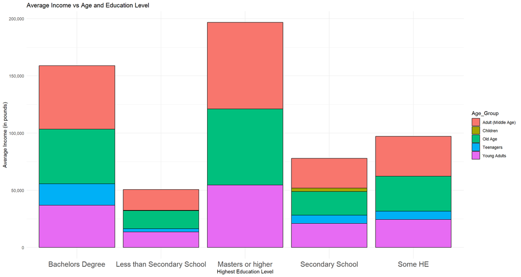

```r
ggplot(Edu_data, aes(x = `Highest Ed`, y = avg_income, fill = `Age_Group`)) +
  geom_bar(stat = "identity", color = 'black') +
  labs(
    title = "Average Income vs Age and Education Level",
    x = "Highest Education Level",
    y = "Average Income (in pounds)"
  ) +
  theme_minimal() +
  scale_y_continuous(labels = scales::comma) +
  theme(axis.text.x = element_text(size=15))
```

## 3.2 Income Distribution by Ethnicity:

Visualizing Income Distribution across different ethnic groups, we observed significant disparities. The data revealed Individuals identified as “White” have higher average income compared to other ethnic groups. Individuals identified as “Black” and “Asian” tend to have lower average incomes. This can be influenced by factors such as educational level and Employment opportunities. This led to the visualization of Income Distribution by Ethnicity and Educational level

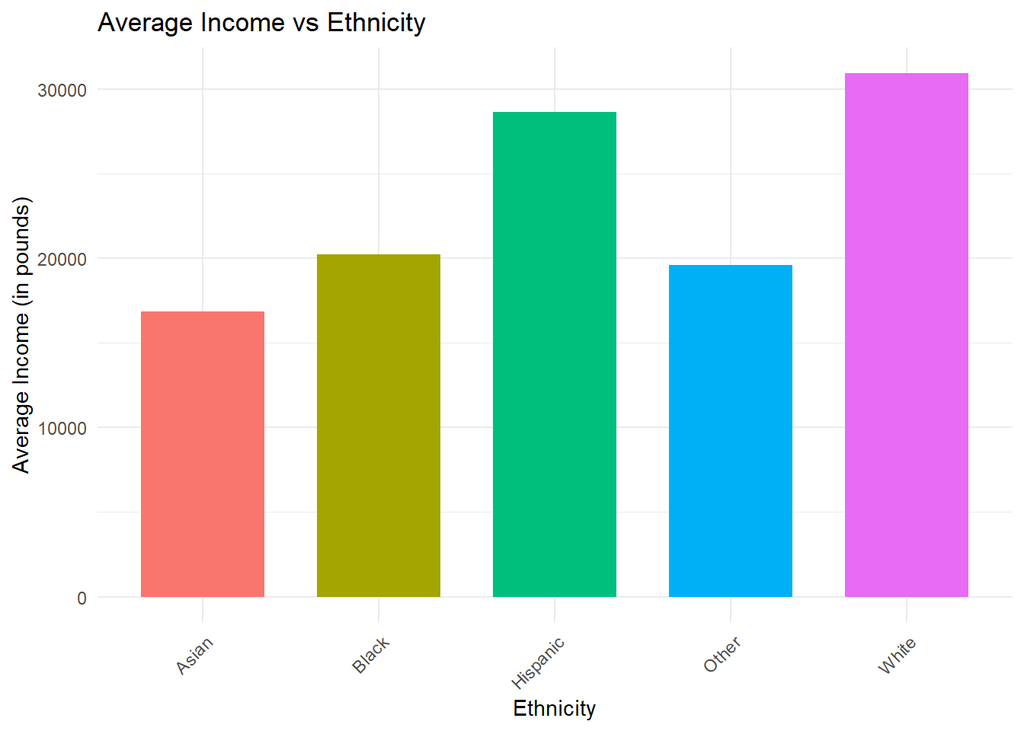

```r
ggplot(newdata1, aes(x = `Eth`, y = INC, fill = `Eth`)) +
  geom_bar(stat = "summary", fun = "mean", position = "dodge", width = 0.7) +
  labs(
    title = "Average Income vs Ethnicity",
    x = "Ethnicity",
    y = "Average Income (in pounds)"
  ) +
  theme_minimal() +
  theme(legend.position = "none") +
  theme(axis.text.x = element_text(angle = 45, hjust = 1))
```

## 3.3 Income Distribution by Ethnicity and Education:

```r
Eth_Edu_data <- newdata1 |>
  group_by(`Highest Ed`, Eth) |>
  summarize(avg_income = mean(INC), n=n())
```

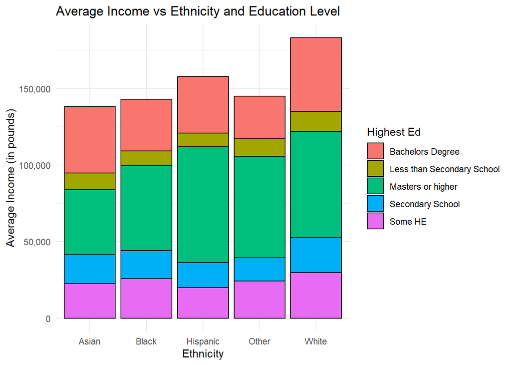

```r
ggplot(Eth_Edu_data, aes(x = `Eth`, y = avg_income, fill = `Highest Ed`)) +
  geom_bar(stat = "identity", color = 'black') +
  labs(
    title = "Average Income vs Ethnicity and Education Level",
    x = "Ethnicity",
    y = "Average Income (in pounds)"
  ) +
  theme_minimal() +
  scale_y_continuous(labels = scales::comma)
```

## 3.4 Income Distribution by Room Accessibility:

Visualizing Income Distribution by room Accessibility, we may observe variations in income levels based on the accessibility of rooms within the accommodation. Households with room exclusivity tend to have higher incomes compared to those without such exclusivity. It can be determined from this that individuals with greater incomes are more likely to be able to afford private accommodations that offer exclusive access.

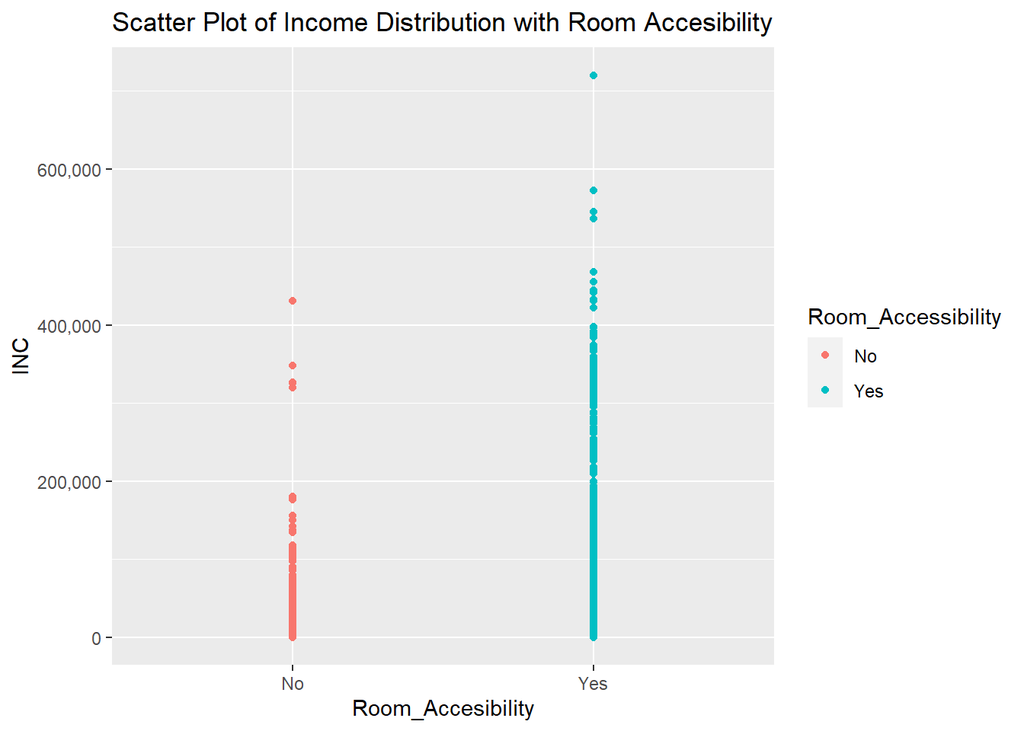

```r
data_3 <- newdata1 |>
  rename(Room_Accessibility = H8)
data_3 <- data_3 |> mutate(Room_Accessibility = ifelse(Room_Accessibility == 1, "No", "Yes"))
#| label: A Scattter/Point plot for income vs Room Accessibility
ggplot(
  data = data_3,
  mapping = aes(x =factor(Room_Accessibility ), y =INC)
)+
  geom_point(aes(color = Room_Accessibility))+
  scale_y_continuous(labels = comma) +
  labs(title = "Scatter Plot of Income Distribution with Room Accesibility",
       x = "Room_Accesibility",y="INC")
```

## 3.5 Income Distribution by Room Accessibility, Ethnicity and Marital Status:

When examining the distribution of income by room accessibility, ethnicity, and marital status, we can observe several interesting patterns, the visualization can provide insights into how income levels and housing dynamics vary across different ethnic groups and marital status. It revealed that most of the individual identified as “White” Predominantly lean towards exclusive room arrangements, with minimal representation from other ethnic groups while only the “Asians” demographic displays a preference for shared accommodations, possibly influenced by cultural factors. (Alavi et al. (2011)) mentioned that older Asians tend to favor residing with their children or other family members rather than living independently, this could be a factor as to why the “Asians” predominantly stay in shared accommodation. We can also observe that those who could afford to live in houses with exclusive room accessibility predominantly couples. This trend suggests that the affordability of such housing arrangements is facilitated by the combined income of couples, making it more feasible compared to single individuals.

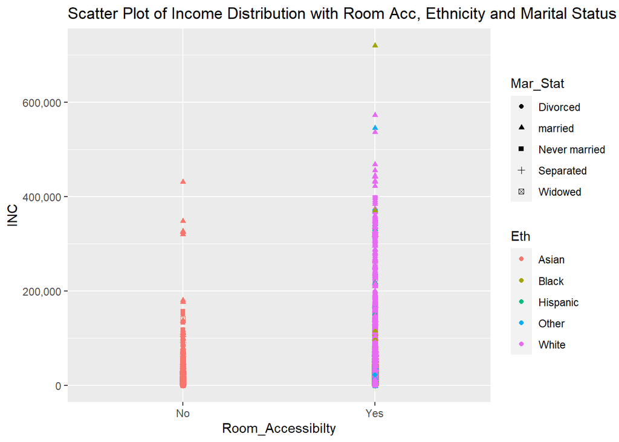

```r
ggplot(
  data = data_3,
  mapping = aes(x = Room_Accessibility, y =INC)
)+
  geom_point(aes(color = Eth, shape=Mar_Stat))+
  scale_y_continuous(labels = comma) +
  labs(title = "Scatter Plot of Income Distribution with Room Acc, Ethnicity and Marital Status",
       x = "Room_Accessibilty",y="INC")
```

# 4 Conclusion

To sum up, this research provides an in-depth understanding of the elements that lead to differences in income. The results highlight the ways in which household, socioeconomic, and demographic factors interact to shape economic inequality. Policymakers are advised to implement focused initiatives in the areas of employment, housing, and education in order to reduce inequalities and promote equality in society.

## 5 References

Alavi, Khadijah, Rahim M Sail, Khairuddin Idris, Asnarulkhadi Abu Samah, and Mustaffa Omar. 2011. “Living Arrangement Preference and Family Relationship Expectation of Elderly Parents.” *Pertanika Journal of Social Science and Humanities* 19 (Special issue): 65–73.

Arnold, Jeffrey B. 2021. “Ggthemes: Extra Themes, Scales and Geoms for ’Ggplot2’.” https://CRAN.R-project.org/package=ggthemes.

Daniels, Shanna, and LaDonna M Thornton. 2020. “Race and Workplace Discrimination: The Mediating Role of Cyber Incivility and Interpersonal Incivility.” *Equality, Diversity and Inclusion: An International Journal* 39 (3): 319–35.

Wickham, Hadley. 2016. “Ggplot2: Elegant Graphics for Data Analysis.” https://ggplot2.tidyverse.org.

Wickham, Hadley, Mara Averick, Jennifer Bryan, Winston Chang, Lucy D’Agostino McGowan, Romain François, Garrett Grolemund, et al. 2019. “Welcome to the Tidyverse” 4: 1686. https://doi.org/10.21105/joss.01686.

Wickham, Hadley, Mine Çetinkaya-Rundel, and Garrett Grolemund. 2023. *R for Data Science*. " O’Reilly Media, Inc.".